# Project: Wrangle and Analyze Data

```python
# Assumption: when at least one values is true, chances are high, there is a dog shown on the picture.
df_p_dog_test_2 = df_image_predictions[(df_image_predictions['p1_dog'] == True) |
                                    (df_image_predictions['p2_dog'] == True) |
                                    (df_image_predictions['p3_dog'] == True)]

df_p_dog_test_2.sample(5)
```

|  | tweet_id | jpg_url | img_num | p1 | p1_conf | p1_dog | p2 | p2_conf | p2_dog | p3 | p3_conf | p3_dog |
| --- | --- | --- | --- | --- | --- | --- | --- | --- | --- | --- | --- | --- |
| 158 | 668872652652679168 | https://pbs.twimg.com/media/CUhQIAhXAAA2j7u.jpg | 1 | teddy | 0.413379 | False | pillow | 0.325623 | False | miniature_schnauzer | 0.035537 | True |
| 399 | 673686845050527744 | https://pbs.twimg.com/media/CVlqi_AXIAASlcD.jpg | 1 | Pekinese | 0.185903 | True | guinea_pig | 0.172951 | False | pug | 0.166183 | True |
| 2061 | 889638837579907072 | https://pbs.twimg.com/media/DFihzFfXsAYGDPR.jpg | 1 | French_bulldog | 0.991650 | True | boxer | 0.002129 | True | Staffordshire_bullterrier | 0.001498 | True |
| 1783 | 829011960981237760 | https://pbs.twimg.com/media/C4E99ygWcAAQpPs.jpg | 2 | boxer | 0.312221 | True | dalmatian | 0.244040 | True | conch | 0.130273 | False |
| 218 | 670073503555706880 | https://pbs.twimg.com/media/CUyUSuWXIAAZKYF.jpg | 1 | malamute | 0.601886 | True | Siberian_husky | 0.340106 | True | Eskimo_dog | 0.050041 | True |

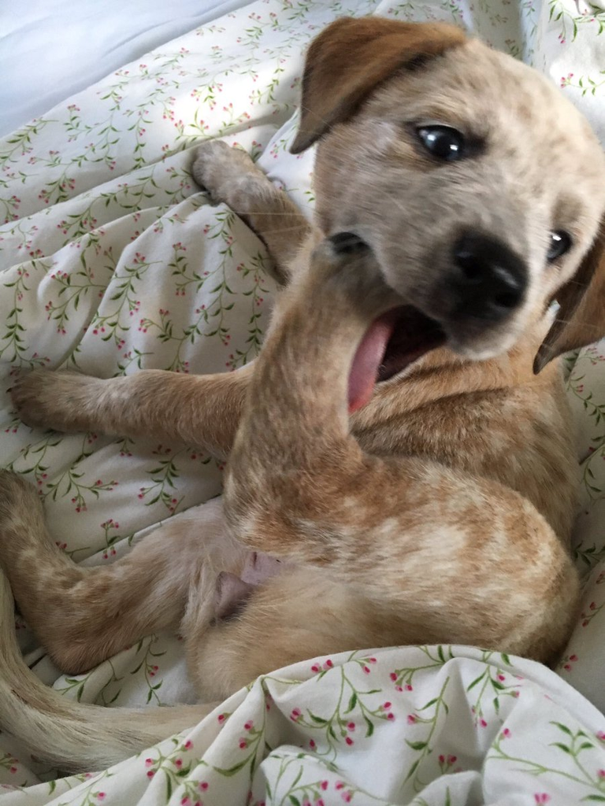

```python
Image("https://pbs.twimg.com/media/C5d0QtvXMAI_7uz.jpg")
```

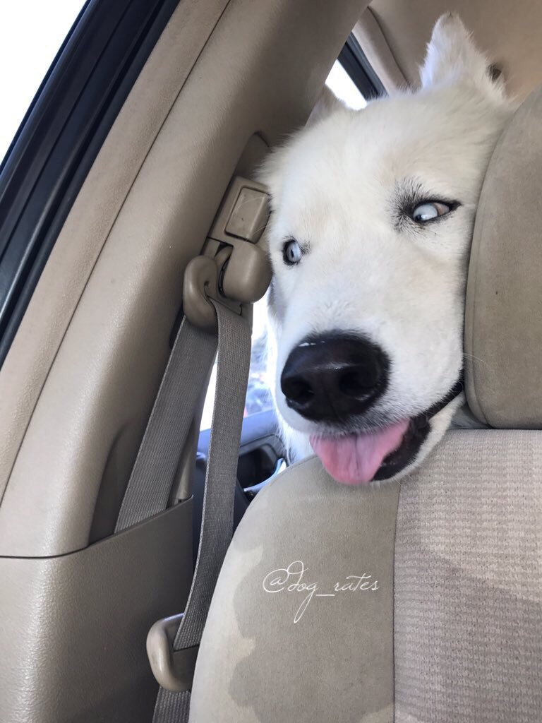

```python
Image("https://pbs.twimg.com/media/CuV8yfxXEAAUlye.jpg")
```

Please note: I personally checked many more URLs per case. These four just demonstrate the manual assessment.

```python
# Mixed capitalization and missused separators among the prediction values.
df_image_predictions.p1.sample(10)
```

```
784                 badger
1605             mousetrap
82                  borzoi
2054        French_bulldog
878                    pug
835                  teddy
1260           tiger_shark
1670              Doberman
1673    Norwegian_elkhound
1407      golden_retriever
Name: p1, dtype: object
```

```python
# The Values in column image_counts do not imply clearly what they are meant for. If know, they might serve for the analysis.
# However, this is not clear to me. I therefore categorize it as a quality issue. The column shall be dropped.
df_image_predictions.img_num.value_counts()
```

```
1    1780
2     198
3      66
4      31
Name: img_num, dtype: int64
```

#### Quality Issues

1. Duplicated image URLs: assessment revealed there are 66 duplicates entries present, however, each pair has a different tweet id. Further assessment showed the same amounts of duplicates among all image prediction value columns, implying that a pair of duplicates is predicated equally. Therefore these duplicates will not be removed. That way, chances are higher that an image prediction is available for each tweet id from the twitter archive dataset.
2. The false values of the columns p1 to p4_dog imply not all images are showing dogs. Manual sampling revealed chances are high the image contains a dog when at least one of the values per is row is true. All other rows shall be deleted.
3. The columns p1, p2, p3 have mixed capitalization. Each first letter of a word will be capitalized. That may also reduce different writings of dog breeds, if existent. This might make the analysis more valid.
4. In the columns p1, p2, p3 single words are separated by an underscore. Underscores will be replaced by spaces.
5. The column img_num will be dropped. The reason, why this is an issue of quality: the values in this column do not explain themselves. They therefore might be misinterpreted and should be excluded as a precaution.

#### Tidiness Issues

1. The columns "p1, p1_conf, p1_dog, etc." have parts of their values in the column titles. The order of the predictions, which is actually a value and cannot be part of the title. To make this tidy, the layout would need to be changed to: "p, p_conf, p_dog" + an additional column "p_order" to state the order of the prediction 1 for the first try, 2 for the second and 3 for the third.
2. The fact that the data of the same observational unit (i.e. the Tweet iself) is stored is present across three separate tables is a tidiness issue. Merging them to one single table is the fix. It also makes analysis easier.

## Cleaning Data

### Table 1: Twitter Archive

#### General preparations and handling the observations

```python
# Creating a copy of the dataset.
df_twitter_archive_cleaned = df_twitter_archive.copy()
```

##### Handling Observation 1

###### Code

```python
df_twitter_archive_cleaned = df_twitter_archive_cleaned[df_twitter_archive_cleaned['timestamp'] <= '2017-08-01']
```

###### Test

```python
df_twitter_archive_cleaned.shape # Check
```

```
(2354, 17)
```

##### Handling Observation 2 to 4

###### Define

Deleting rows with retweets and responses. For structual and logical reasons, they will not be part of analysis. Once the values are dropped, the columns can also be dropped.

###### Code

```python
df_twitter_archive_cleaned = df_twitter_archive_cleaned[df_twitter_archive_cleaned['in_reply_to_status_id'].isnull()]
df_twitter_archive_cleaned = df_twitter_archive_cleaned[df_twitter_archive_cleaned['retweeted_status_id'].isnull()]

columns_to_be_dropped = ["in_reply_to_status_id", "in_reply_to_user_id", "retweeted_status_id", "retweeted_status_user_id", "retweeted_status_timestamp" ]
df_twitter_archive_cleaned.drop(columns_to_be_dropped, axis = 1, inplace=True)
columns_to_be_dropped = []
```

###### Test

```python
print(df_twitter_archive_cleaned.info()) #Check
```

```
<class 'pandas.core.frame.DataFrame'>
Int64Index: 2095 entries, 2 to 2355
Data columns (total 12 columns):
tweet_id              2095 non-null int64
timestamp             2095 non-null object
source                2095 non-null object
text                  2095 non-null object
expanded_urls         2092 non-null object
rating_numerator      2095 non-null int64
rating_denominator    2095 non-null int64
name                  2095 non-null object
doggo                 2095 non-null object
floofer               2095 non-null object
pupper                2095 non-null object
puppo                 2095 non-null object
dtypes: int64(3), object(9)
memory usage: 212.8+ KB
None
```

#### Fixing Quality Issues

##### Fixing Quality Issue 1

###### Define

Deleting rows with empty values in column expanded_urls.

###### Code

```python
df_twitter_archive_cleaned['expanded_urls'].dropna(how = "all", inplace=True)
```

###### Test

```python
print(df_twitter_archive_cleaned.info())
```

```
<class 'pandas.core.frame.DataFrame'>
Int64Index: 2095 entries, 2 to 2355
Data columns (total 12 columns):
tweet_id              2095 non-null int64
timestamp             2095 non-null object
source                2095 non-null object
text                  2095 non-null object
expanded_urls         2092 non-null object
rating_numerator      2095 non-null int64
rating_denominator    2095 non-null int64
name                  2095 non-null object
doggo                 2095 non-null object
floofer               2095 non-null object
pupper                2095 non-null object
puppo                 2095 non-null object
dtypes: int64(3), object(9)
memory usage: 212.8+ KB
None
```

There are still only 2092 instead of 2095 values counted in that column. Maybe pandas got the datatype wrong, while loading from the CSV-File.

Detailed check:

```python
sum(df_twitter_archive_cleaned.expanded_urls == "")
```

```
0
```

This appears odd. I therefore like ensure, the column is assigned the string datatype.

```python
df_twitter_archive_cleaned['expanded_urls'] = df_twitter_archive_cleaned['expanded_urls'].astype(str)
```

Reverse Test

```python
sum(df_twitter_archive_cleaned.expanded_urls != "")
```

```
2095
```

###### Final test

```python
print(df_twitter_archive_cleaned.info()) #Check
```

```
<class 'pandas.core.frame.DataFrame'>
Int64Index: 2095 entries, 2 to 2355
Data columns (total 12 columns):
tweet_id              2095 non-null int64
timestamp             2095 non-null object
source                2095 non-null object
text                  2095 non-null object
expanded_urls         2092 non-null object
rating_numerator      2095 non-null int64
rating_denominator    2095 non-null int64
name                  2095 non-null object
doggo                 2095 non-null object
floofer               2095 non-null object
pupper                2095 non-null object
puppo                 2095 non-null object
dtypes: int64(3), object(9)
memory usage: 212.8+ KB
None
```

##### Fixing Quality Issue 2

###### Define

Deleting redundant information from the column expanded_urls. Some rows contain the value twice, separated by a comma.

###### Code

```python
df_twitter_archive_cleaned.expanded_urls.value_counts()
```

```
https://vine.co/v/ea0OwvPTx9l                                                                                                                                                                      2
https://twitter.com/dog_rates/status/748324050481647620/photo/1,https://twitter.com/dog_rates/status/748324050481647620/photo/1                                                                    1
https://twitter.com/dog_rates/status/766008592277377025/photo/1                                                                                                                                    1
https://twitter.com/dog_rates/status/666044226329800704/photo/1                                                                                                                                    1
https://twitter.com/dog_rates/status/684940049151070208/photo/1,https://twitter.com/dog_rates/status/684940049151070208/photo/1                                                                    1
https://twitter.com/dog_rates/status/693647888581312512/photo/1                                                                                                                                    1
https://twitter.com/dog_rates/status/754120377874386944/photo/1                                                                                                                                    1
https://twitter.com/dog_rates/status/670465786746662913/photo/1                                                                                                                                    1
https://twitter.com/dog_rates/status/739606147276148736/photo/1,https://twitter.com/dog_rates/status/739606147276148736/photo/1,https://twitter.com/dog_rates/status/739606147276148736/photo/1    1
https://twitter.com/dog_rates/status/699088579889332224/photo/1                                                                                                                                    1
https://twitter.com/dog_rates/status/756303284449767430/photo/1                                                                                                                                    1
https://twitter.com/dog_rates/status/742423170473463808/photo/1                                                                                                                                    1
https://twitter.com/dog_rates/status/666099513787052032/photo/1                                                                                                                                    1
https://twitter.com/dog_rates/status/673656262056419329/photo/1                                                                                                                                    1
https://twitter.com/dog_rates/status/693262851218264065/photo/1                                                                                                                                    1
https://twitter.com/dog_rates/status/671497587707535361/photo/1                                                                                                                                    1
https://twitter.com/dog_rates/status/774757898236878852/photo/1                                                                                                                                    1
https://twitter.com/dog_rates/status/771014301343748096/photo/1                                                                                                                                    1
https://twitter.com/dog_rates/status/715009755312439296/photo/1                                                                                                                                    1
https://twitter.com/dog_rates/status/680130881361686529/photo/1                                                                                                                                    1
https://twitter.com/dog_rates/status/698549713696649216/photo/1                                                                                                                                    1
https://twitter.com/dog_rates/status/707411934438625280/photo/1                                                                                                                                    1
https://twitter.com/dog_rates/status/667902449697558528/photo/1                                                                                                                                    1
https://twitter.com/dog_rates/status/676089483918516224/photo/1                                                                                                                                    1
https://twitter.com/dog_rates/status/677716515794329600/photo/1                                                                                                                                    1
https://twitter.com/dog_rates/status/813142292504645637/photo/1,https://twitter.com/dog_rates/status/813142292504645637/photo/1,https://twitter.com/dog_rates/status/813142292504645637/photo/1    1
https://twitter.com/dog_rates/status/672205392827572224/photo/1                                                                                                                                    1
```

[output cut: 35 more lines]

```python
df_twitter_archive_cleaned['expanded_urls_cleaned'] = df_twitter_archive_cleaned.expanded_urls.str.split(',').str[0]
df_twitter_archive_cleaned.drop('expanded_urls', axis = 1, inplace=True)
df_twitter_archive_cleaned.rename(columns={'expanded_urls_cleaned':'expanded_url'}, inplace=True)
```

###### Test

```python
df_twitter_archive_cleaned.info()
```

```
<class 'pandas.core.frame.DataFrame'>
Int64Index: 2095 entries, 2 to 2355
Data columns (total 12 columns):
tweet_id              2095 non-null int64
timestamp             2095 non-null object
source                2095 non-null object
text                  2095 non-null object
rating_numerator      2095 non-null int64
rating_denominator    2095 non-null int64
name                  2095 non-null object
doggo                 2095 non-null object
floofer               2095 non-null object
pupper                2095 non-null object
puppo                 2095 non-null object
expanded_url          2092 non-null object
dtypes: int64(3), object(9)
memory usage: 212.8+ KB
```

##### Fixing Quality Issue 3

###### Define

Delete rows with duplicate expanded_urls, in case there are still some left.

###### Code

```python
df_twitter_archive_cleaned.drop_duplicates(subset="expanded_url", inplace=True)
```

###### Test

```python
sum(df_twitter_archive_cleaned.duplicated(subset="expanded_url"))
```

```
0
```

##### Fixing Quality Issue 4

###### Define

Deleting rows with illogical values in the columns rating_numerator and rating_denominator.

###### Code

```python
df_twitter_archive_cleaned  = df_twitter_archive_cleaned[(df_twitter_archive_cleaned.rating_numerator < 20)
                                                         & (df_twitter_archive_cleaned.rating_numerator > 1)]
```

```python
# df_numerator_check serves for later checking
df_numerator_check = df_twitter_archive_cleaned[(df_twitter_archive_cleaned.rating_numerator > 20) |
                                                (df_twitter_archive_cleaned.rating_numerator < 1)]
```

```python
df_twitter_archive_cleaned  = df_twitter_archive_cleaned[(df_twitter_archive_cleaned.rating_denominator < 20)
                                                         & (df_twitter_archive_cleaned.rating_denominator > 1)]
```

```python
# df_nominator_check serves for later checking
df_denominator_check = df_twitter_archive_cleaned[(df_twitter_archive_cleaned.rating_denominator > 20)
                                                  | (df_twitter_archive_cleaned.rating_denominator < 1)]
```

###### Test

```python
df_numerator_check.shape # Must be zero rows now.
```

```
(0, 12)
```

```python
df_numerator_check.shape # Must be zero rows now.
```

```
(0, 12)
```

```python
df_twitter_archive_cleaned.shape # Check - must be less rows in total now.
```

```
(2067, 12)
```

##### Fixing Quality Issue 5

###### Define

Merging columns rating_numerator and rating_denominator.

###### Code

```python
df_twitter_archive_cleaned['rating'] = df_twitter_archive_cleaned.rating_numerator / df_twitter_archive_cleaned.rating_denominator

#Dropping factor columns
columns_to_be_dropped = []
columns_to_be_dropped = ["rating_numerator", "rating_denominator"]
df_twitter_archive_cleaned.drop(columns_to_be_dropped, axis = 1, inplace=True)
columns_to_be_dropped = []
```

###### Test

```python
df_twitter_archive_cleaned.rating.value_counts() # Check if calculation is correct
```

```
1.200000    486
1.000000    434
1.100000    413
1.300000    284
0.900000    152
0.800000     98
0.700000     51
1.400000     38
0.500000     34
0.600000     32
0.300000     19
0.400000     15
0.200000      9
0.818182      1
0.636364      1
Name: rating, dtype: int64
```

```python
df_twitter_archive_cleaned.info() # Check if column has been inserted properly.
```

```
<class 'pandas.core.frame.DataFrame'>
Int64Index: 2067 entries, 2 to 2355
Data columns (total 11 columns):
tweet_id        2067 non-null int64
timestamp       2067 non-null object
source          2067 non-null object
text            2067 non-null object
name            2067 non-null object
doggo           2067 non-null object
floofer         2067 non-null object
pupper          2067 non-null object
puppo           2067 non-null object
expanded_url    2066 non-null object
rating          2067 non-null float64
dtypes: float64(1), int64(1), object(9)
memory usage: 193.8+ KB
```

##### Fixing Quality Issue 6

###### Define

Dropping column source and name.

###### Code

```python
columns_to_be_dropped = ["source", "name"]
df_twitter_archive_cleaned.drop(columns_to_be_dropped, axis = 1, inplace=True)
columns_to_be_dropped = []
```

###### Test

```python
print(df_twitter_archive_cleaned.info()) #Check
```

```
<class 'pandas.core.frame.DataFrame'>
Int64Index: 2067 entries, 2 to 2355
Data columns (total 9 columns):
tweet_id        2067 non-null int64
timestamp       2067 non-null object
text            2067 non-null object
doggo           2067 non-null object
floofer         2067 non-null object
pupper          2067 non-null object
puppo           2067 non-null object
expanded_url    2066 non-null object
rating          2067 non-null float64
dtypes: float64(1), int64(1), object(7)
memory usage: 161.5+ KB
None
```

#### Tidiness Issues

##### Fixing Tidiness Issue 1 (optional)

No need to separate Tweets of replies and retweets from the archive table. They have been deleted, as they will not be part of the analysis by definition.

##### Fixing Tidiness Issue 2 (optional)

###### Define

Dropping columns with special classifications. They are not needed for this particular (my) analysis.

###### Code

```python
columns_to_be_dropped = []
columns_to_be_dropped = ["doggo", "floofer", "pupper", "puppo"]
df_twitter_archive_cleaned.drop(columns_to_be_dropped, axis = 1, inplace=True)
columns_to_be_dropped = []
```

###### Test

```python
df_twitter_archive_cleaned.info() # Check
```

```
<class 'pandas.core.frame.DataFrame'>
Int64Index: 2067 entries, 2 to 2355
Data columns (total 5 columns):
tweet_id        2067 non-null int64
timestamp       2067 non-null object
text            2067 non-null object
expanded_url    2066 non-null object
rating          2067 non-null float64
dtypes: float64(1), int64(1), object(3)
memory usage: 96.9+ KB
```